# Using Self-Organizing Maps with `SOMbrero` to cluster a numeric dataset

A couple of plots from `plot.somRes` are also available for the super clustering. Some identify the super clusters with colors:

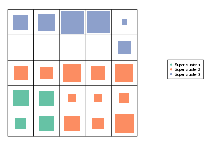

```r
plot(my.sc, type = "hitmap", plot.legend = TRUE)
```

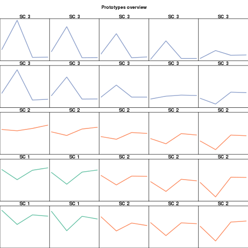

```r
plot(my.sc, type = "lines", print.title = TRUE)
```

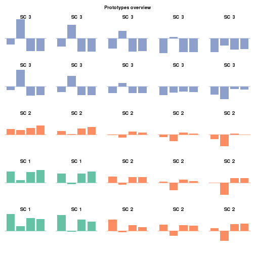

```r
plot(my.sc, type = "barplot", print.title = TRUE)
```

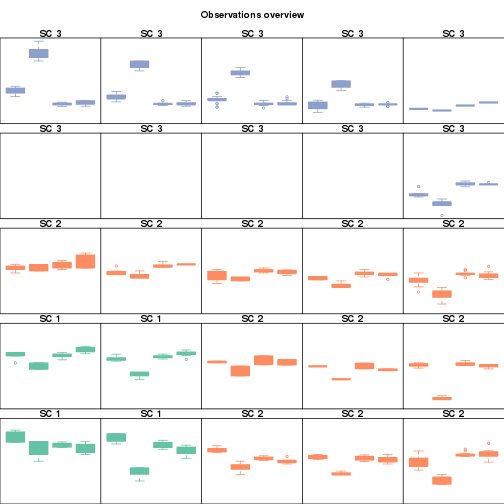

```r
plot(my.sc, type = "boxplot", print.title = TRUE)
```

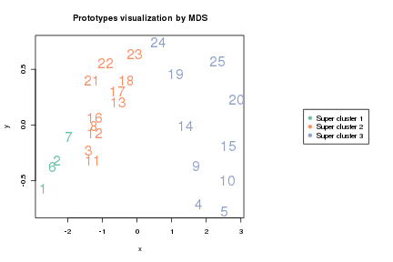

```r
plot(my.sc, type = "mds", plot.legend = TRUE, cex = 2)
```

And some others identify the super clusters with titles:

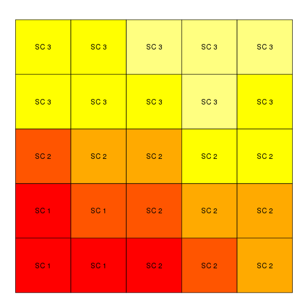

```r
plot(my.sc, type = "color")
```

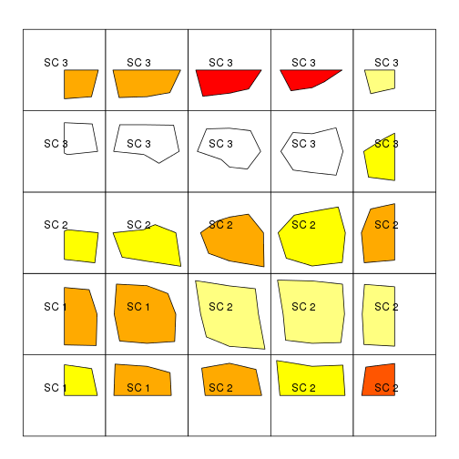

```r
plot(my.sc, type = "poly.dist")
```

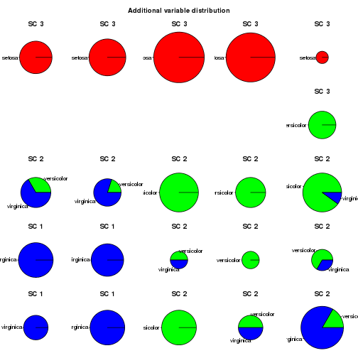

```r
plot(my.sc, type = "pie", variable = iris$Species)
```

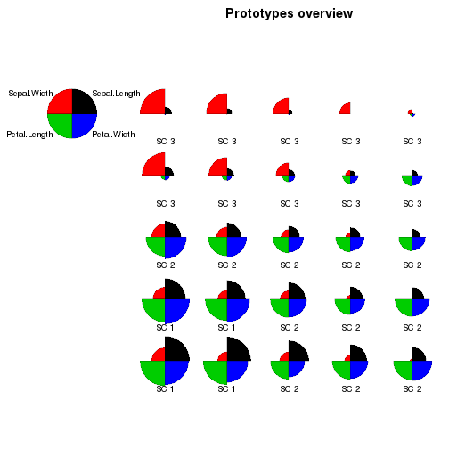

```r
plot(my.sc, type = "radar", key.loc = c(-0.5, 5), mar = c(0, 10, 2, 0))
```

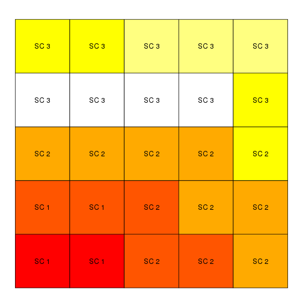

```r
plot(my.sc, type = "color", add.type = TRUE, variable = iris$Sepal.Length)
```

All these graphics help to see that super-cluster number 1 is found in the lower left corner of the map and contains only flowers of the “verginica” species. Super cluster number 3, on the top of the map, contains mostly flowers of the “setosa” species. The last super-cluster is located in the half right part of the map and contains flowers of the species “versicolor” and “virginica”.